# Scaffa_report

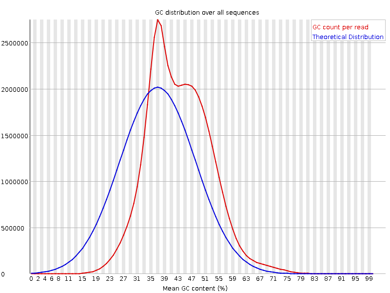

GroupA_IgG_2

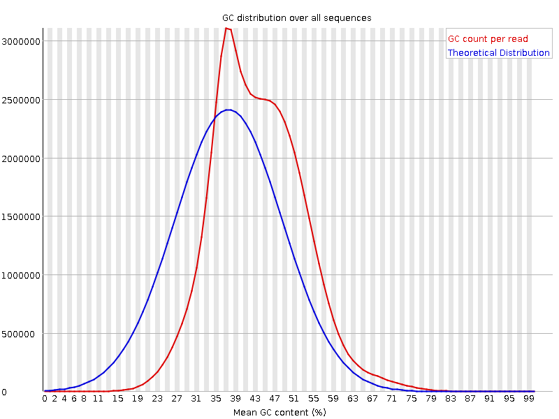

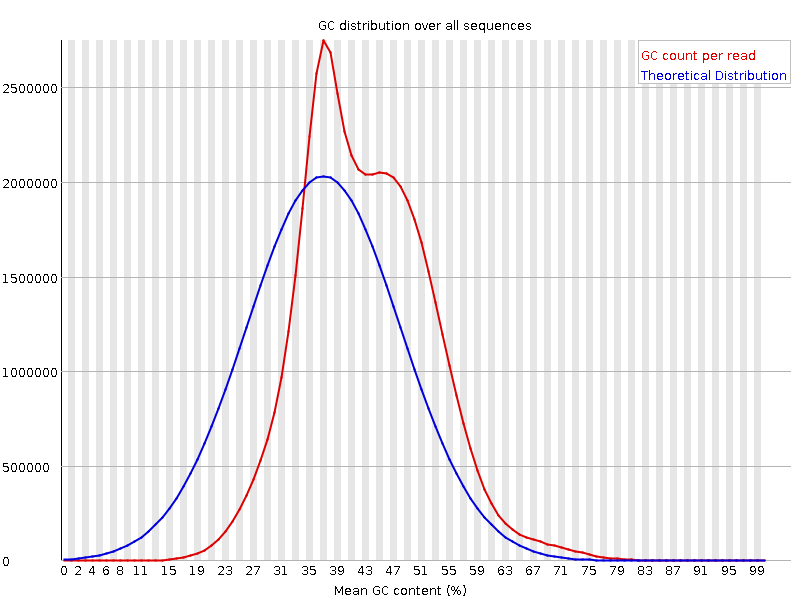

GroupA_HO1_1

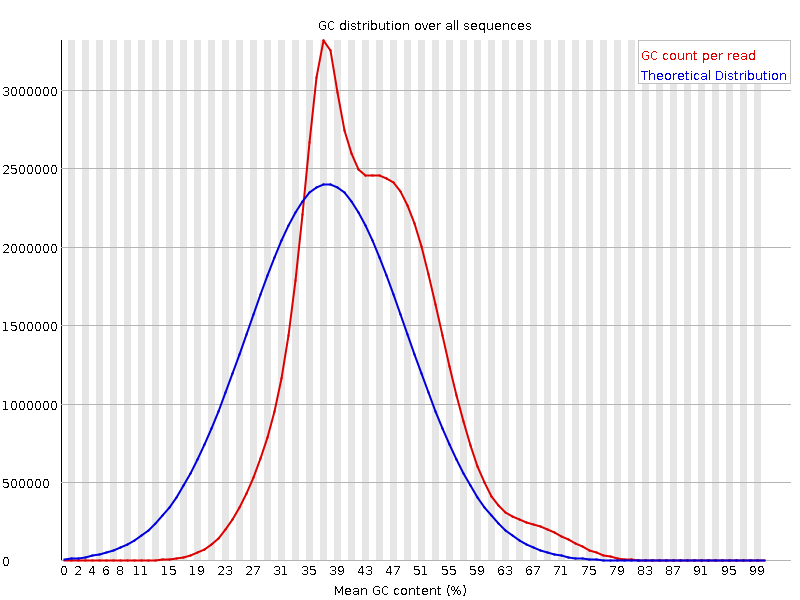

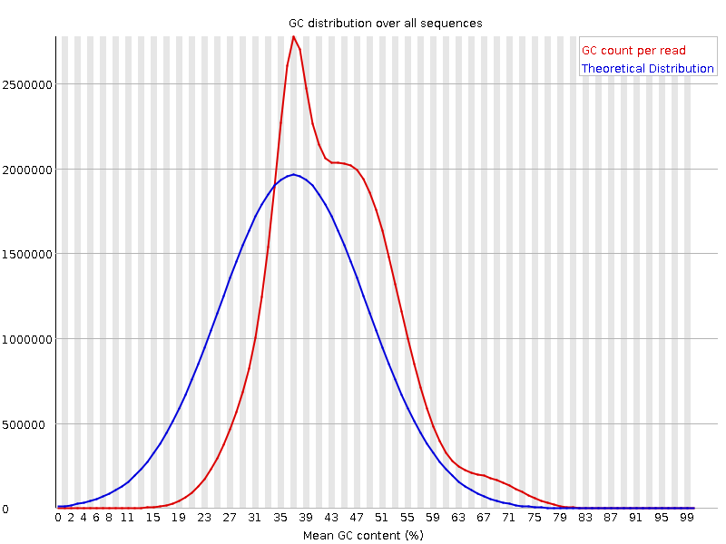

GroupA_HO1_2

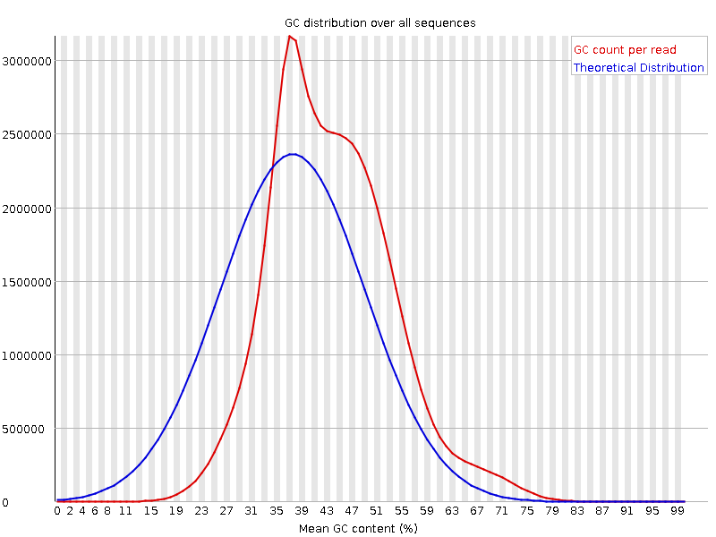

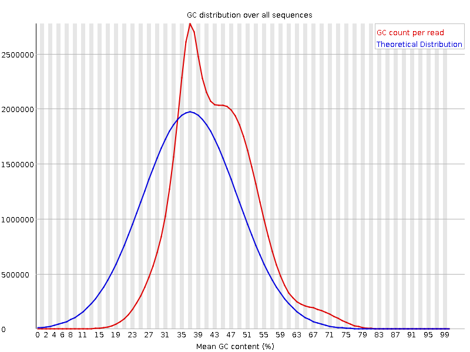

GroupB_H20_1

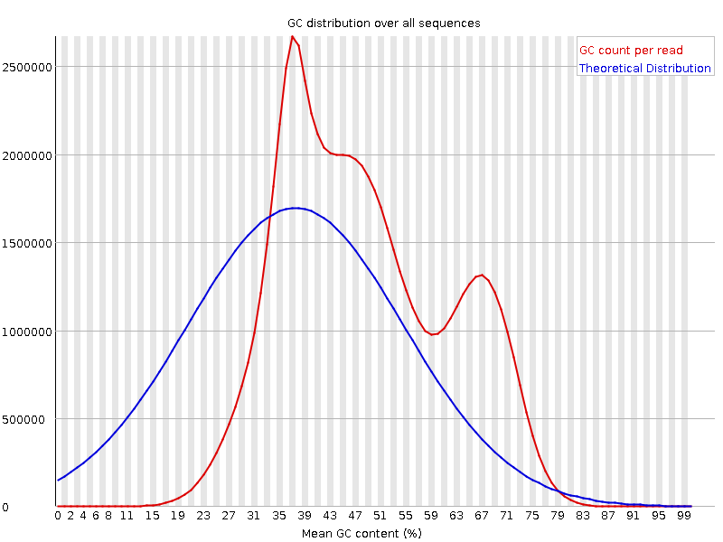

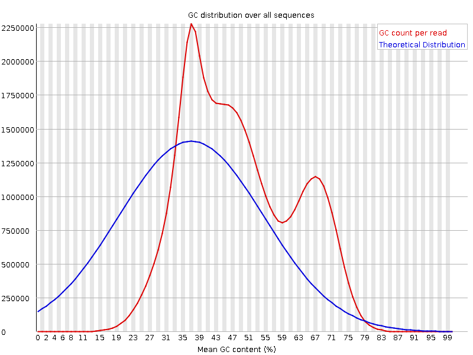

GroupB_H20_2

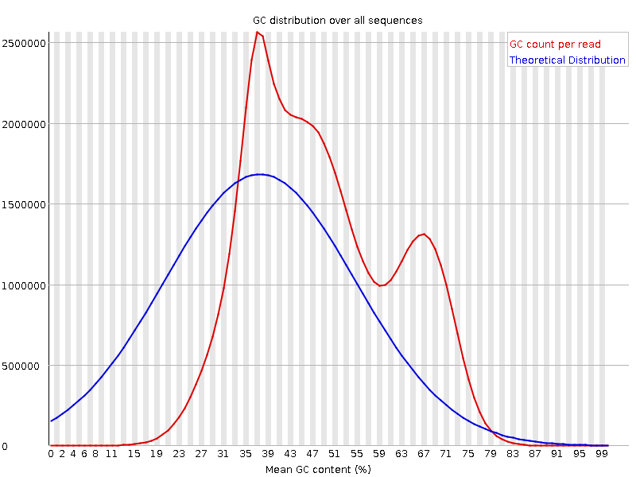

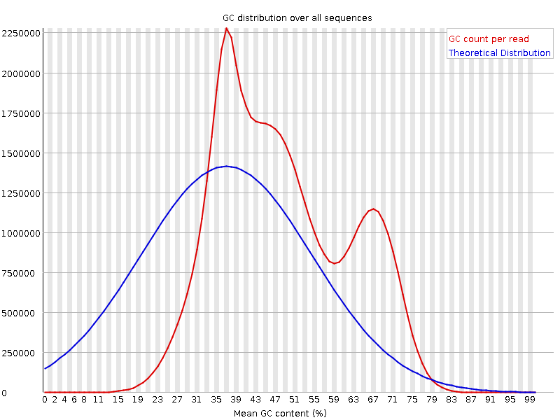

GroupB_IgG_1

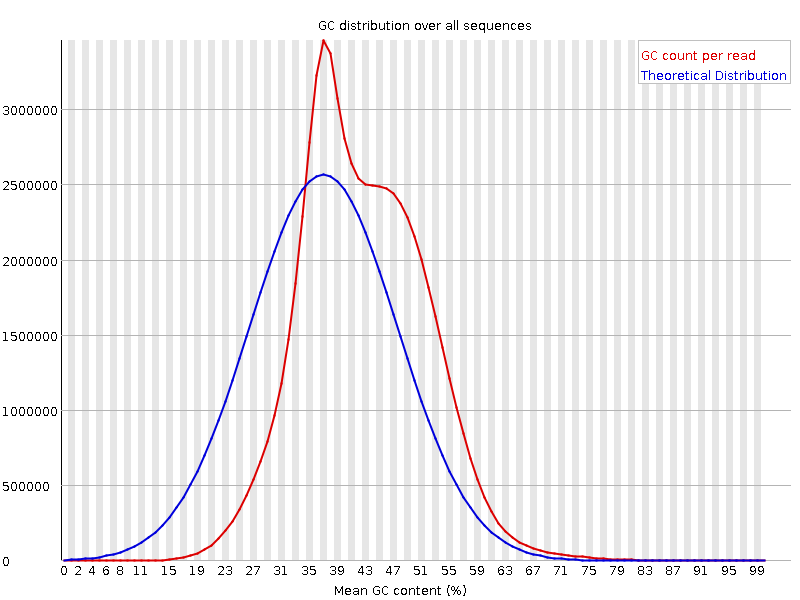

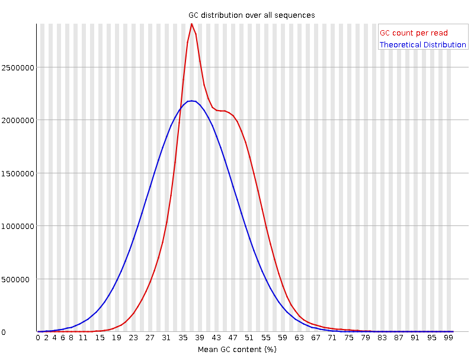

GroupB_IgG_2

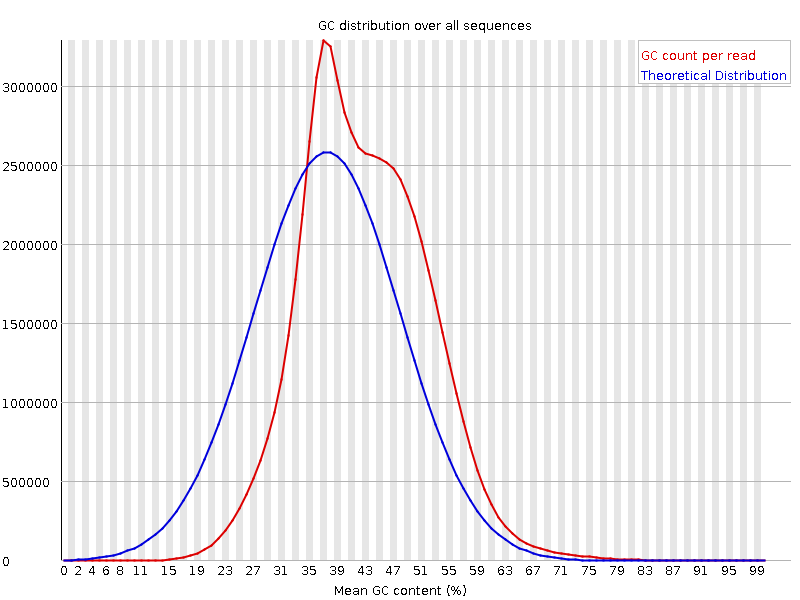

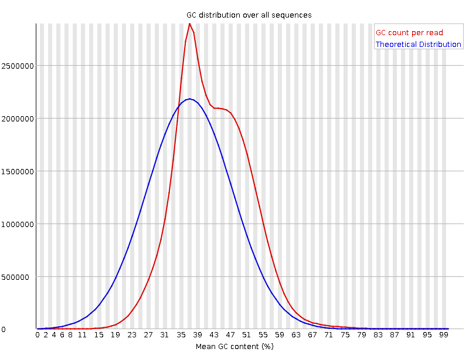

GroupB_HO1_1

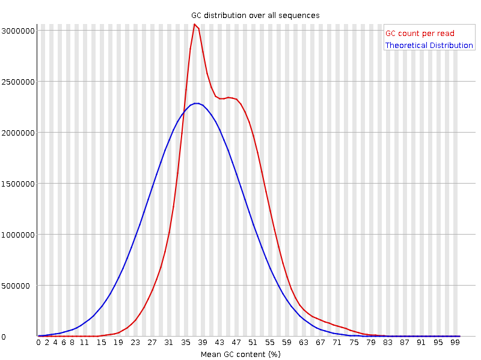

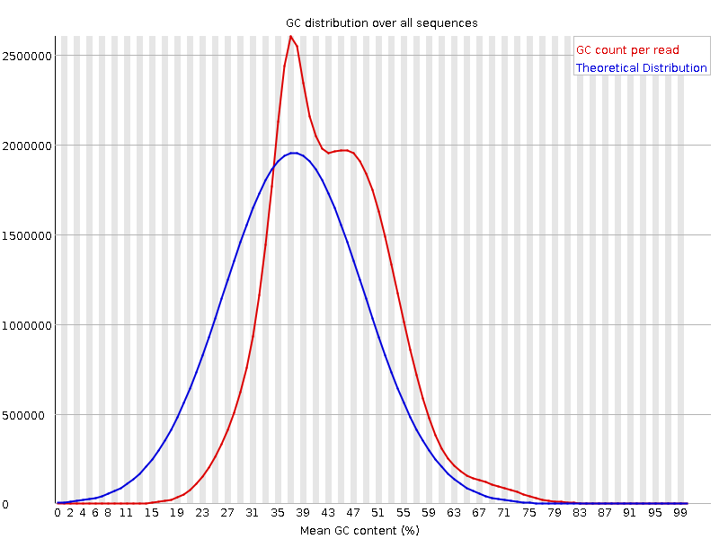

GroupB_HO1_2

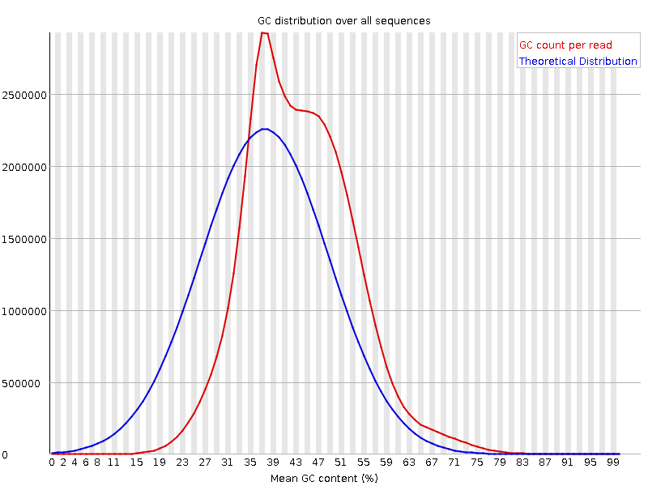

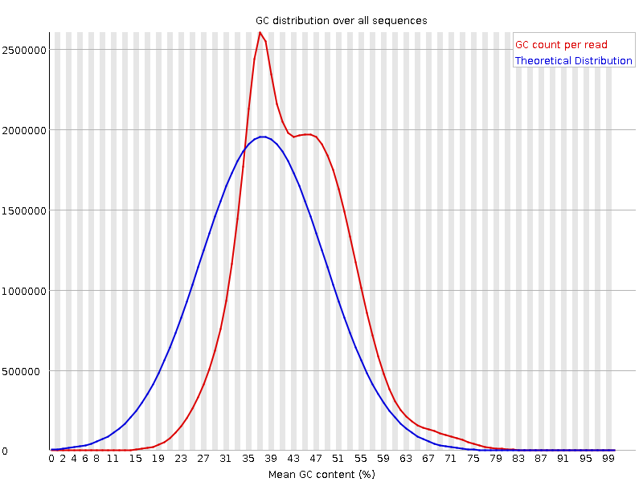

## Part 5: Kmer content plots

**Library**

**Raw reads**

**Trimmed reads**

GroupA_LH20_1

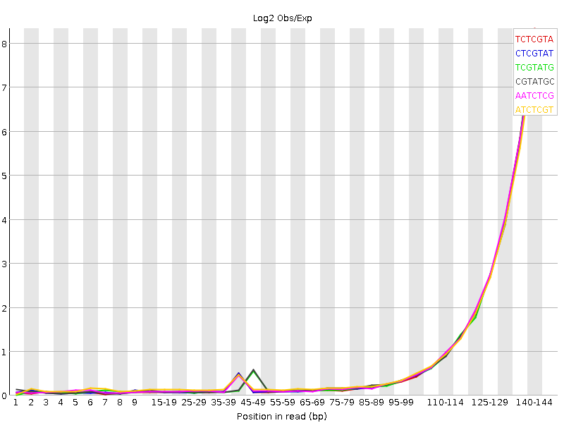

No enriched Kmers

GroupA_LH20_2

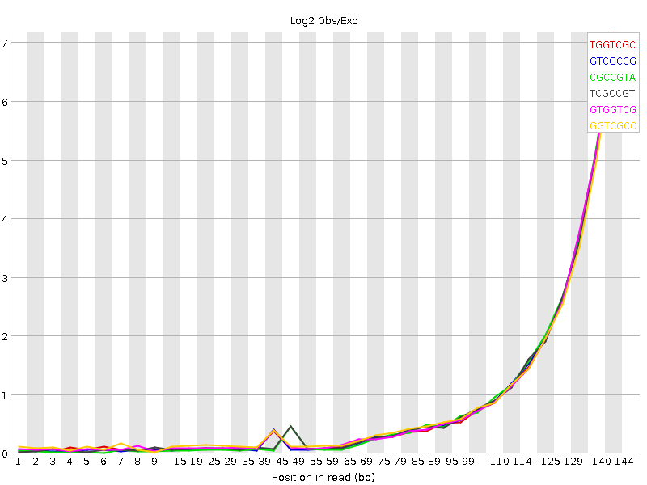

No enriched Kmers

GroupA_IgG_1

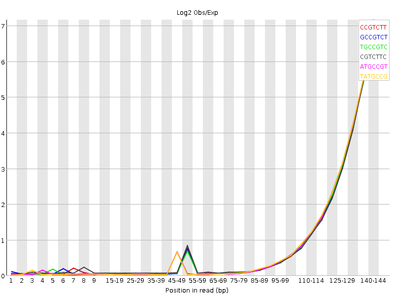

No enriched Kmers

GroupA_IgG_2

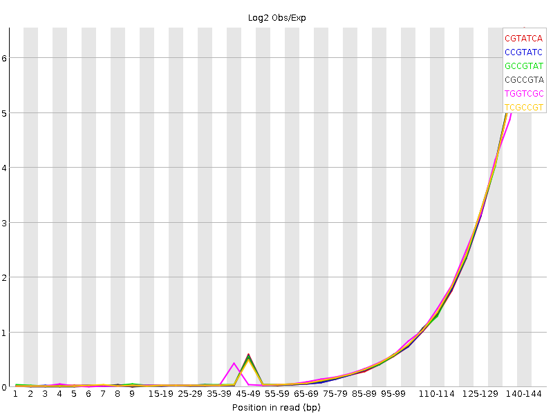

No enriched Kmers

GroupA_HO1_1

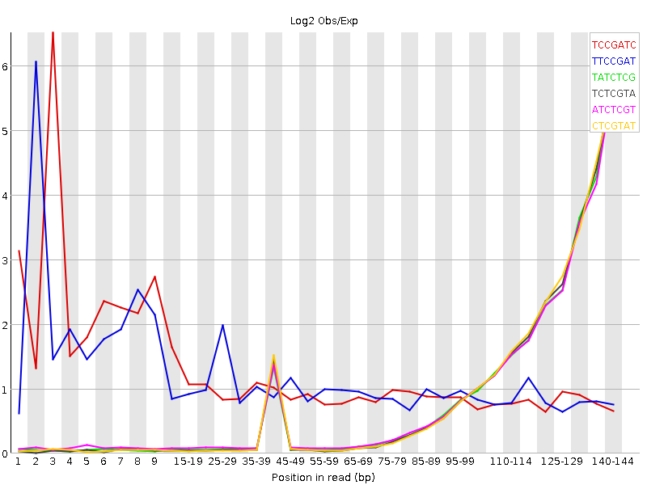

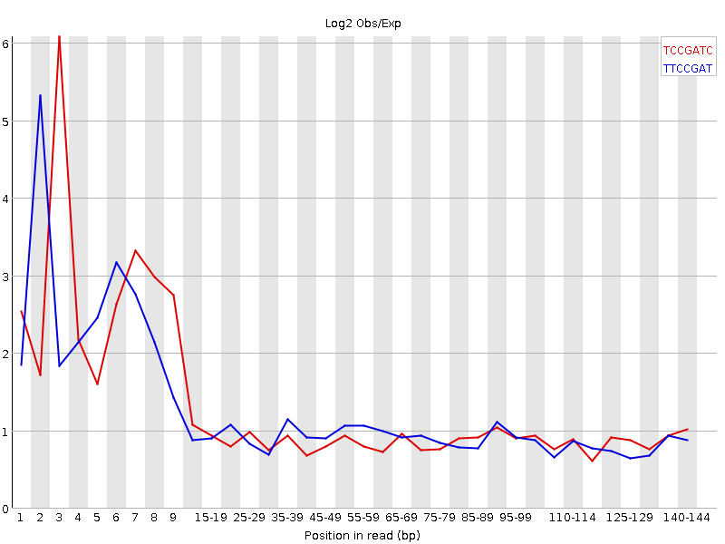

GroupA_HO1_2

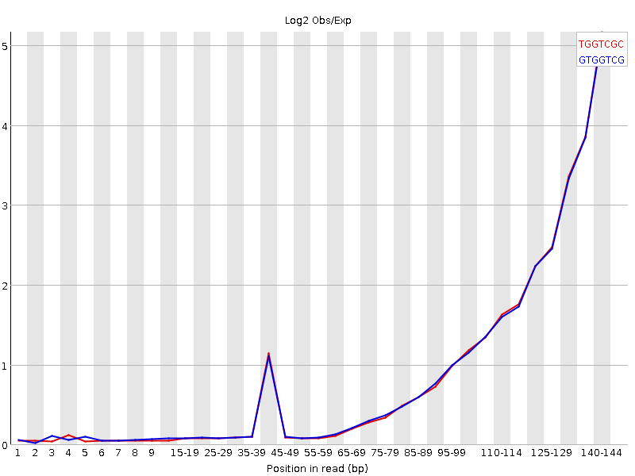

No enriched Kmers

GroupB_H20_1

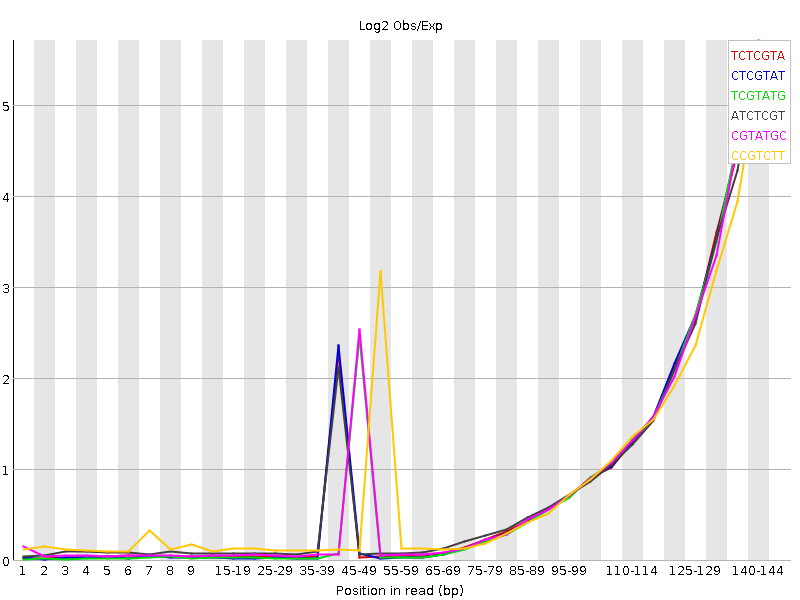

No enriched Kmers

GroupB_H20_2

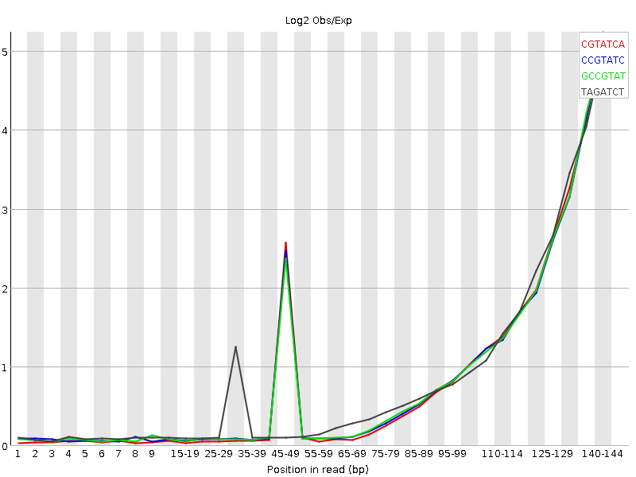

No enriched Kmers

GroupB_IgG_1

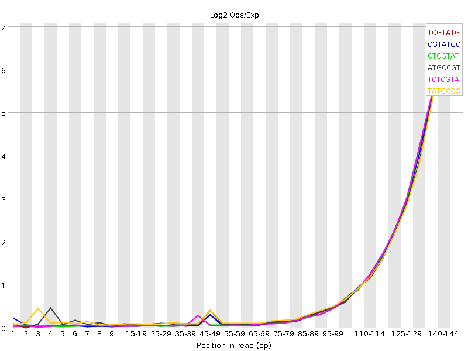

No enriched Kmers

GroupB_IgG_2

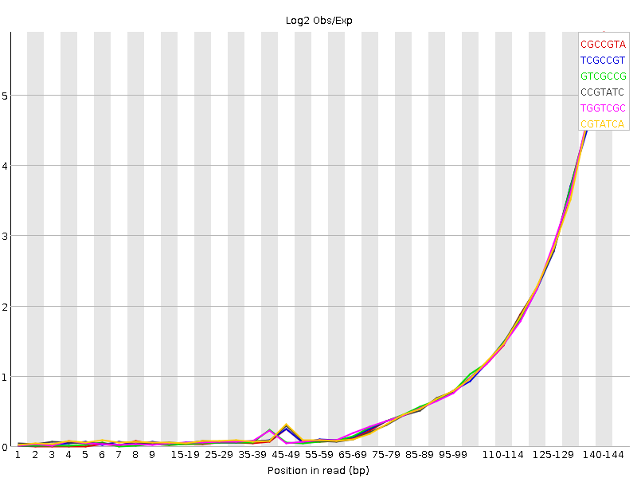

No enriched Kmers

GroupB_HO1_1

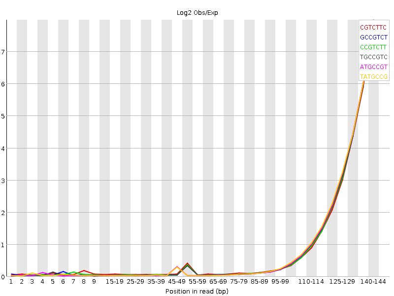

No enriched Kmers

GroupB_HO1_2

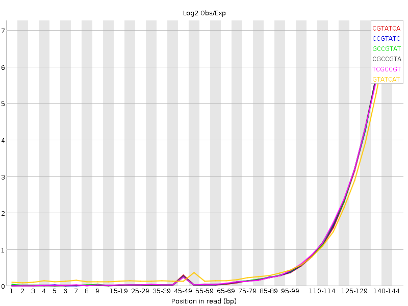

No enriched Kmers

## Part 5A: Kmer content table - GroupA_HO1_1 Trimmed reads

| **Sequence** | **Count** | **p-value** | **Obs/Exp Max** | **Max Obs/Exp Position** |
| --- | --- | --- | --- | --- |
| TCCGATC | 6000 | 0.0 | 6.081754 | 3 |
| TTCCGAT | 6720 | 0.0 | 5.327682 | 2 |

## Part 6: Read QC summary

- Trimming improved the overall read quality scores (Part 3).
- All libraries have two peaks around 40% and 50% mean GC content. (Part 4).
- GroupB_H20_1 and GroupB_H20_2 libraries have an additional peak around 70% mean GC content, which is not mediated by trimming based on quality, adapter presence, or sequence length (Part 4).
- All raw reads show some degree of enrichmed kmers (adapter sequence) and most of the enriched kmers are removed after trimming (Part 5).
- GroupA_HO1 library still has some enriched kmers after trimming, but their counts are low (~6000), suggesting that they should not significantly impact downstream analyses (Part 5A).

## Part 7: Read alignment

- Trimmed reads were aligned against the Ensembl assembly GRCm38.p6 (`/gpfs/data/cbc/references/Ensembl_M_musculus.GRCm38.p6`).
- Reference indexing (`bwa index`)and read mapping (`bwa mem -M`) were performed in bwa (V0.7.15).
- Subsequent SAM conversion to BAM (`samtools view -Sbh`), as well as BAM sorting (`samtools sort`) and indexing (`samtools index`) were performed in Samtools (V1.9).
- Duplicates were marked (`MarkDuplicates`) and alignment statistics (`CollectAlignmentSummaryMetrics`, `CollectWGSMetrics`) were extracted using Picard tools (V2.9.2).
- For more information on Picard tools metrics reported here, see https://broadinstitute.github.io/picard/picard-metric-definitions.html

## Part 8: Alignment summary statistics

| **LIBRARY** | **TOTAL_READS** | **READS_ALIGNED_IN_PAIRS** |
| --- | --- | --- |
| GroupA_LH20 | 120247798 | 119552802 |
| GroupA_IgG | 111144462 | 109848730 |
| GroupA_HO1 | 113732244 | 110567302 |
| GroupB_H20 | 123133088 | 98219504 |
| GroupB_IgG | 113044822 | 112704592 |
| GroupB_HO1 | 107337628 | 105711984 |

- LIBRARY: The library for which statistics are reported.
- TOTAL_READS: The total number of reads including all PF and non-PF reads. When CATEGORY equals PAIR this value will be 2x the number of clusters.
- READS_ALIGNED_IN_PAIRS: The number of aligned reads whose mate pair was also aligned to the reference.

## Part 9: WGS summary statistics

| **LIBRARY** | **MEAN_COVERAGE** | **SD_COVERAGE** | **PCT_EXC_MAPQ** | **PCT_EXC_UNPAIRED** | **PCT_EXC_BASEQ** | **PCT_EXC_OVERLAP** | **PCT_EXC_CAPPED** | **PCT_EXC_TOTAL** |  |
| --- | --- | --- | --- | --- | --- | --- | --- | --- | --- |
| GroupA_LH20 | 3.74 | 3.42 | 0.11 | 1.10E-04 | 7.14E-03 | 0.27 | 0.011 | 0.40 |  |
| GroupA_IgG | 3.67 | 3.24 | 0.12 | 1.60E-04 | 7.81E-03 | 0.20 | 0.013 | 0.34 |  |
| GroupA_HO1 | 3.80 | 3.40 | 0.11 | 3.64E-04 | 8.05E-03 | 0.20 | 0.013 | 0.33 |  |
| GroupB_H20 | 2.93 | 3.46 | 0.12 | 7.12E-04 | 7.55E-03 | 0.22 | 0.014 | 0.36 |  |
| GroupB_IgG | 3.98 | 3.33 | 0.11 | 7.50E-05 | 8.08E-03 | 0.18 | 0.013 | 0.32 |  |
| GroupB_HO1 | 3.39 | 3.08 | 0.11 | 1.92E-04 | 7.62E-03 | 0.22 | 0.013 | 0.36 |  |

- LIBRARY: The library for which statistics are reported.
- MEAN_COVERAGE: The mean coverage in bases of the genome territory, after all filters are applied.
- SD_COVERAGE: The standard deviation of coverage of the genome after all filters are applied.
- MEDIAN_COVERAGE: The median coverage in bases of the genome territory, after all filters are applied.
- PCT_EXC_MAPQ: The fraction of aligned bases that were filtered out because they were in reads with low mapping quality (default is < 20).
- PCT_EXC_DUPE: The fraction of aligned bases that were filtered out because they were in reads marked as duplicates.
- PCT_EXC_UNPAIRED: The fraction of aligned bases that were filtered out because they were in reads without a mapped mate pair.
- PCT_EXC_BASEQ: The fraction of aligned bases that were filtered out because they were of low base quality (default is < 20).
- PCT_EXC_OVERLAP: The fraction of aligned bases that were filtered out because they were the second observation from an insert with overlapping reads.
- PCT_EXC_CAPPED: The fraction of aligned bases that were filtered out because they would have raised coverage above the capped value (default cap = 250x).
- PCT_EXC_TOTAL: The total fraction of aligned bases excluded due to all filters.

## Part 10: Duplication statistics

| **LIBRARY** | **READ_PAIRS_EXAMINED** | **SECONDARY_OR_SUPPLEMENTARY_RDS** | **UNMAPPED_READS** | **PERCENT_DUPLICATION** | **ESTIMATED_LIBRARY_SIZE** |
| --- | --- | --- | --- | --- | --- |
| GroupA_LH20 | 59776401 | 681633 | 659975 | 0.16 | 178349158 |
| GroupA_IgG | 54924365 | 604280 | 1264843 | 0.18 | 135069209 |
| GroupA_HO1 | 55283651 | 649083 | 3101149 | 0.22 | 110761630 |
| GroupB_H20 | 49109752 | 415352 | 24781602 | 0.38 | 47614157 |
| GroupB_IgG | 56352296 | 581808 | 320129 | 0.15 | 172478062 |
| GroupB_HO1 | 52855992 | 607151 | 1592490 | 0.17 | 138855851 |

- LIBRARY: The library on which the duplicate marking was performed.
- READ_PAIRS_EXAMINED: The number of mapped read pairs examined.
- SECONDARY_OR_SUPPLEMENTARY_RDS: The number of reads that were either secondary or supplementary
- UNMAPPED_READS: The total number of unmapped reads examined.
- PERCENT_DUPLICATION: The fraction of mapped sequence that is marked as duplicate.
- ESTIMATED_LIBRARY_SIZE: The estimated number of unique molecules in the library based on PE duplication.

## Part 12: Peak calling using MACS2

- Used MACS2 (V 2.1.2) for peak calling.
- Used the input libraries (H20 and LH20) as controls, while the IgG and HO1 libraries were considered treatments.
- Each treatment was compared to both control files.
- The following additional flags were used:
- `-f BAMPE` to specify that the libraries were paired-end
- `-g mm` to specify that the *Mus musculus* pre-built specs should be used to estimate genome size
- `-p 1e-3` a slightly relaxed p-value was used so that we would recover more peaks (with the understanding that we could filter out low p-values later if necessary)

## Part 13: Overlapping peaks

- Using ChipPeakAnno (V3.16.1) We calculated a permissive and conservative estimate of the peaks that overlap between HO1 and IgG (`findOverlapsOfPeaks`).
- The conservative estimate is based on comparing all of the ChIP libraries (HO1 and IgG) to both input libraries (GroupA LH20 and GroupB H20) to make peak calls.
- It requires that a list of peaks be present in all HO1 peak calls but not both of the IgG peak calls.
- This convervative estimate finds 38 peaks specific to HO1.
- A more permissive estimate is based on all the GroupA and GroupB ChIP libraries but input control from GroupA only, as there were some issues with the GroupB input library having more unmapped reads.
- This more permissive estimate finds 211 peaks specific to HO1.
- All analyses from this point forward are based on this more permissive set.

## Part 15: Testing for significance of peaks

- Plotted the distribution of q-value scores across the permissive peaks (Part 13).
- The qvalue is a corrected p-value score. The FDR cutoff is 0.05 and it uses the Benjamini-Hochberg procedure.

### GroupA q-value distribution

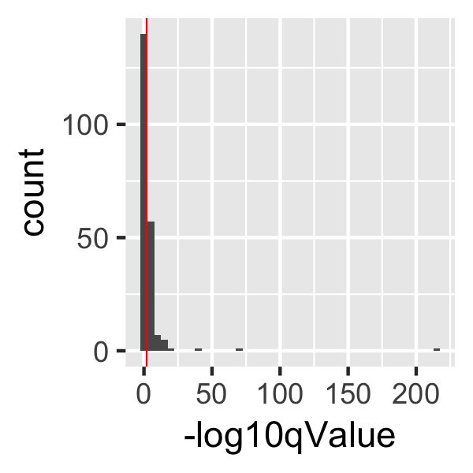

### GroupB q-value distribution

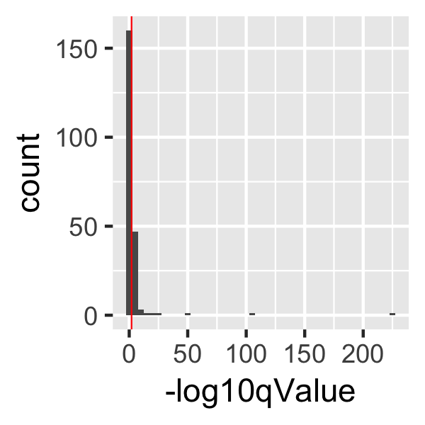

- The x-axis is the -log10 q-value reported by MACS2.
- The red line indicates where the -log10 of the q-value is equal to 2 (corresponds to a q-value of ~0.01).
- Some of the peaks have -log10 q-values larger than this value.

## Part 16: Peak locations in the context of genomic features

- To determine the peak locations in the context of genomic features, we used ChipSeeker `plotAnnoPie` and `plotDisttoTSS`.

**plotAnnoPie**

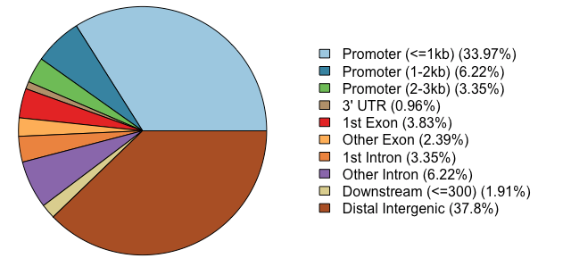

**plotDisttoTSS**

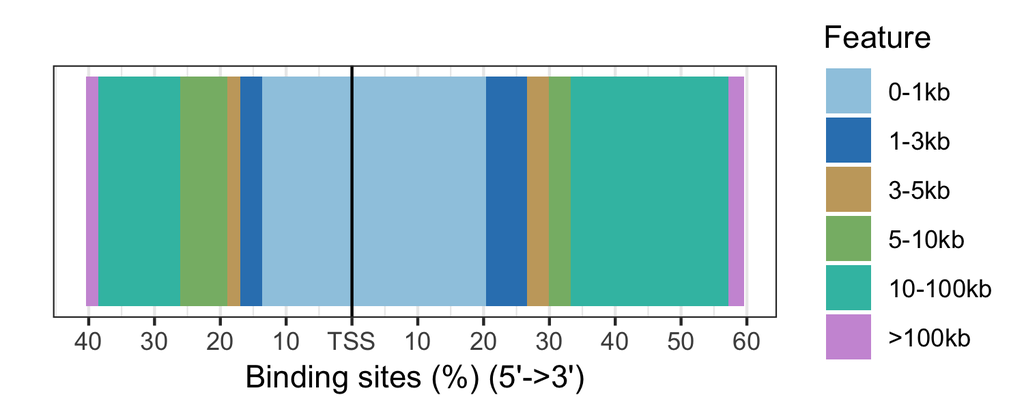

- These figures suggest that most of the HO1-specific peaks are either less than 1KB from a promoter/TSS or in distal intergenic regions (10-100kb from promoter/TSS).

## Part 17: Peaks per chromosome

- Plotted histograms to get a better understanding of the distribution of peaks across chromosomes.

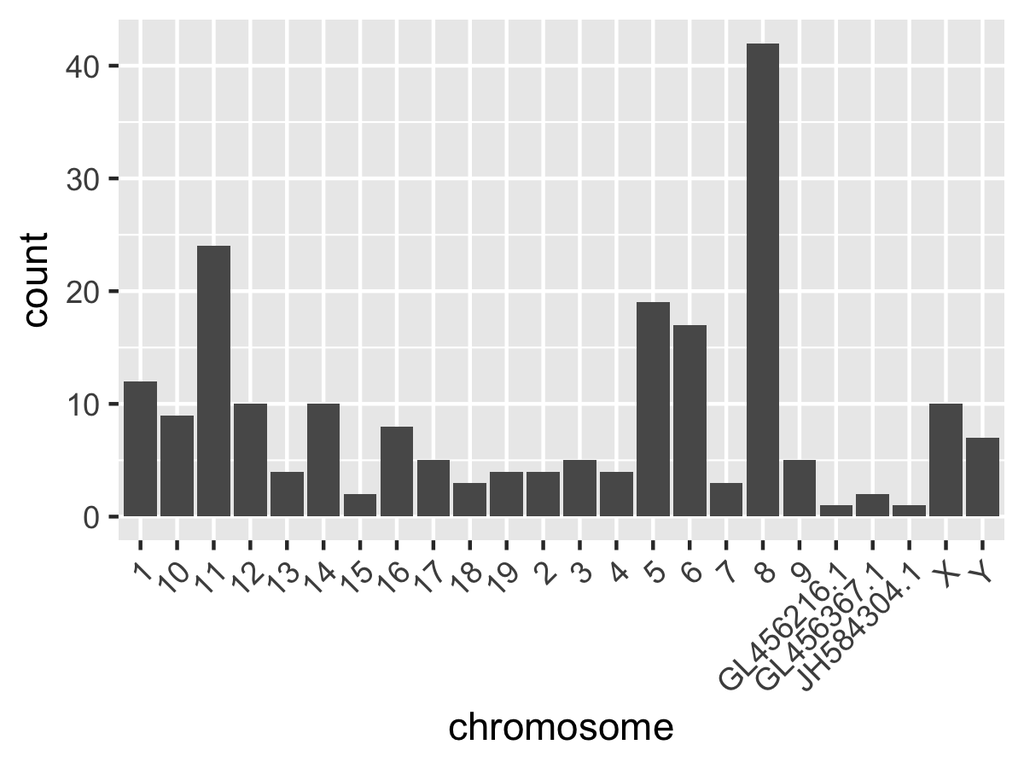

* The peaks are not evenly distributed across all chromosomes.

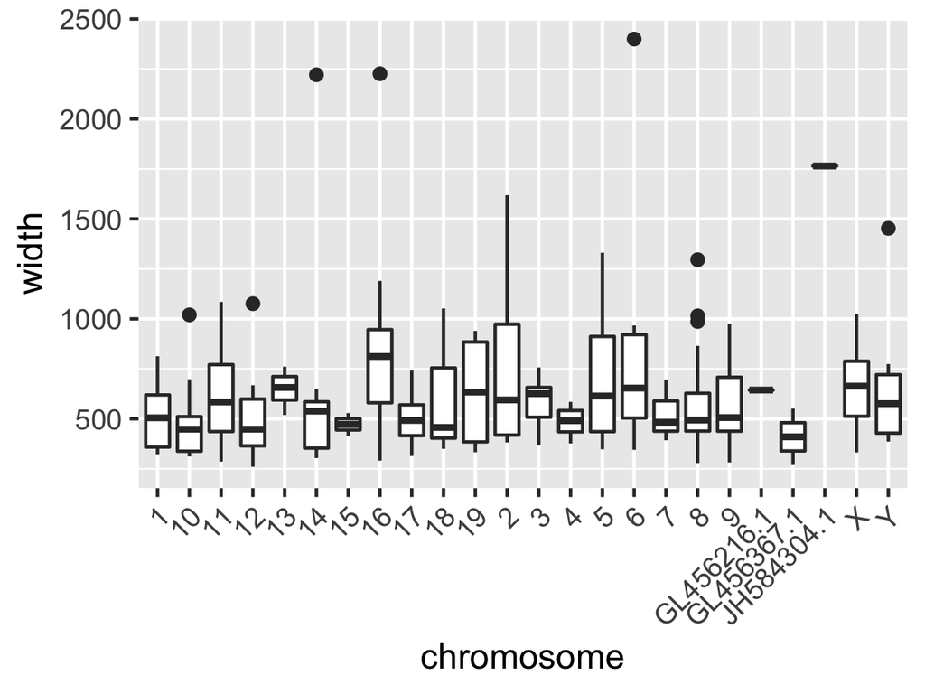

* Although there is some variation, peaks are generally less than 1kb in width.